# Machine Learning Project

Noel Temena

August 17, 2017

Six young health participants were asked to perform one set of 10 repetitions of the Unilateral Dumbbell Biceps Curl in five different fashions:

Class A : exactly according to the specification  
Class B : throwing the elbows to the front  
Class C : lifting the dumbbell only halfway  
Class D : lowering the dumbbell only halfway  
Class E : throwing the hips to the front

### Goal:

Predict the manner in which they did the exercise.

### Dataset

Training data: https://d396qusza40orc.cloudfront.net/predmachlearn/pml-training.csv

Test data: https://d396qusza40orc.cloudfront.net/predmachlearn/pml-testing.csv

### Model Methodology

Outcome variable “CLASSE” has a factor data structure (A,B,C,D,E). This variable, a categorical data will be best predicted using any classifier predictive method. Since the Coursera course have used random forest extensively, I will start with using Random forest and compare it against SVM using C-classification.

### Cross Validation

I will be using K-fold cross validation with k = 3 value. Using the for loop, the **program will create 3 distinct sets of training and test data**. This will produce 3 model fit values which will be averaged to establish an average accuracy.

### Expected out of sample error

Ideally out of sample error rate should be 0% and accuracy rate to be 100%. In predictive data analysis anywhere between 70% and 99% accuracy and 30% to 1% out of sample error rate or **MISCLASSIFICATION RATE** is acceptable.

To get the out of sample error rate: 1 - accuracy rate

Lets start by loading all the libraries

```r
library(caret)
library(readr)
library(mlbench)
library(e1071)
```

Read the training and test data

```r
allData <- read_csv('pml-training.csv',col_names = TRUE,na=c("NA","#DIV/0!", ""))
allDataTest <- read_csv('pml-testing.csv',col_names = TRUE,na=c("NA","#DIV/0!", ""))
```

Clean the Data by using only column with no missing values

```r
allData <-allData[,colSums(is.na(allData)) == 0]
allDataTest <-allDataTest[,colSums(is.na(allDataTest)) == 0]
```

Take out unnecessary columns that has no corelation to the outcome variable

```r
allData   <-allData[,-c(1:7)]
allDataTest <-allDataTest[,-c(1:7)]
```

Show the structure of CLASSE variable

```r
class(allData$classe)
```

```
## [1] "character"
```

```r
table(allData$classe)# ABCDE
```

```
##
##    A    B    C    D    E
## 5580 3797 3422 3216 3607
```

Now that we have establish the data structure for the Classe variable and confirm that its a **categorical data**, we will use Random forest and SVM to build a model.

Before we begin to model in Random forest,lets load parallel processing to speed up the results.

```r
library(parallel)
library(doParallel)
cluster <- makeCluster(detectCores() - 1) # convention to leave 1 core for OS
registerDoParallel(cluster)
#Configure trainControl object
fitControl <- trainControl(method = "cv", number = 3, allowParallel = TRUE)
```

Start Cross validation

```r
set.seed(333)
folds <- createFolds(allData$classe,k= 3)
Accu1_array <- array()## accuracy value storage
```

Create 3 distinct data sets, get the model, predict and get accuracy for each iteration

```r
for(i in 1:3)
{
    data_train <- allData[(-folds[[i]]),]
    data_test  <- allData[(folds[[i]]),]
    fit_rf <- train(factor(classe) ~., method="rf", data= data_train, trControl = fitControl)
    pred_rf <- predict(fit_rf,data_test)
    cm <- confusionMatrix(pred_rf,data_test$classe)
    Accu1_array[i] <- as.numeric(cm$overall['Accuracy'])
}
```

Stop parallel instance and plot predicted classe outcome

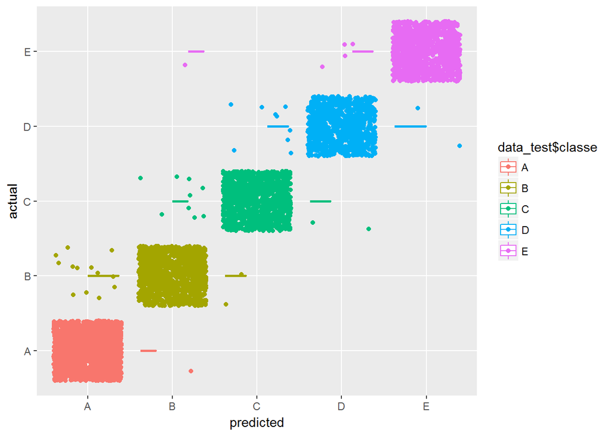

```r
stopCluster(cluster)
registerDoSEQ()
qplot(pred_rf,factor(data_test$classe), xlab = "predicted", ylab = "actual", colour= data_test$classe,geom = c("boxplot", "jitter"))
```

Get mean of the 3 accuracy and show Out of Sample Rate

```r
mean(Accu1_array) #93% SVM 99% for RF
```

```
## [1] 0.9923048
```

```r
1- mean(Accu1_array)
```

```
## [1] 0.007695247
```

As you can see, mean accuracy of the 3 Random forest model is *99.2%* with *.7%* out of sample error.

Now lets try SVM model.

Start Cross validation

```r
set.seed(999)
folds <- createFolds(allData$classe,k= 3)
Accu2_array <- array()## accuracy value storage
```

Create 3 distinct data sets, get the model, predict and get accuracy for each iteration

```r
for(i in 1:3)
{
    data_train <- allData[(-folds[[i]]),]
    data_test  <- allData[(folds[[i]]),]
    fit_svm <- svm(classe ~., method="svm", data= data_train, type= "C-classification")
    pred_svm <- predict(fit_svm,data_test)
    cm <- confusionMatrix(pred_svm,data_test$classe)
    Accu2_array[i] <- as.numeric(cm$overall['Accuracy'])
}
```

Plot predicted SVM classe

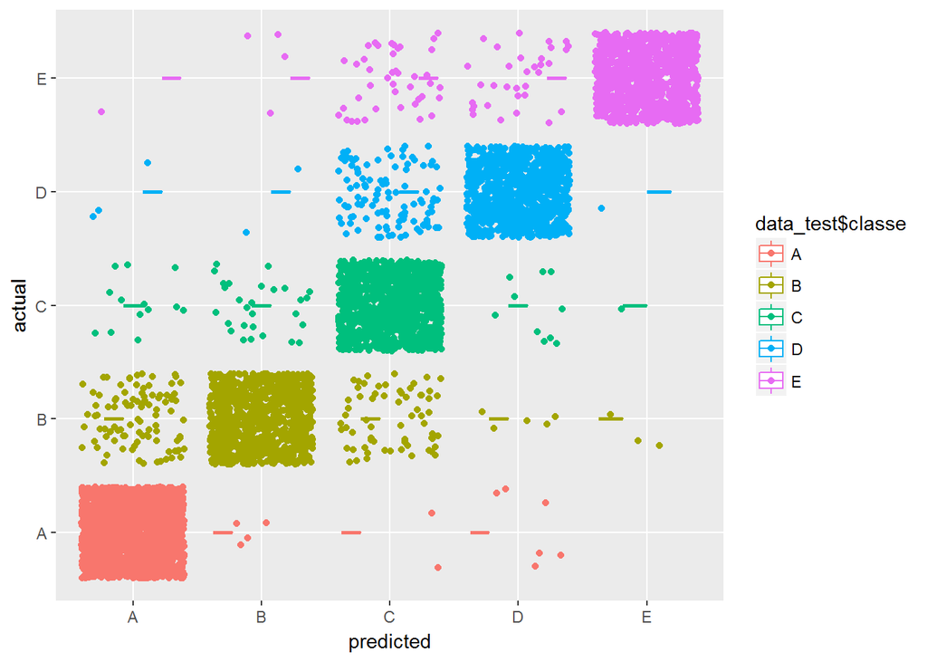

```r
qplot(pred_svm,factor(data_test$classe), xlab = "predicted", ylab = "actual", colour= data_test$classe,geom = c("boxplot", "jitter"))
```

Get mean of the 3 accuracy and show Out of Sample Rate.

```r
mean(Accu2_array) #93% SVM 99% for RF
```

```
## [1] 0.9337992
```

```r
1- mean(Accu2_array)
```

```
## [1] 0.06620082
```

Mean accuracy of the 3 SVM model is *93.3%* with *6.6%* out of sample error.

*Clearly Random forest model with 99% accuracy is the most accurate.*

So lets apply this final RF model to predict the AllDataTest with 20 rows.

```r
final_rf <- predict(fit_rf,allDataTest )
final_rf
```

```
##  [1] B A B A A E D B A A B C B A E E A B B B
## Levels: A B C D E
```

*Credits:* IGreski for the parallel processing: https://github.com/lgreski/datasciencectacontent/blob/master/markdown/pml-randomForestPerformance.md

DATASET: Bulling, A.; Gellersen, H.; Ugulino, W.; Fuks, H.Qualitative Activity Recognition of Weight Lifting Exercises. Proceedings of 4th International Conference in Cooperation with SIGCHI (Augmented Human ’13) . Stuttgart, Germany: ACM SIGCHI, 2013. (DATASET)